# Diversification - Clive

## Exercise 1: Can we estimate speciation and extinction with confidence?

```r
rm(list = ls())
library(geiger)
library(phytools)
library(diversitree)
```

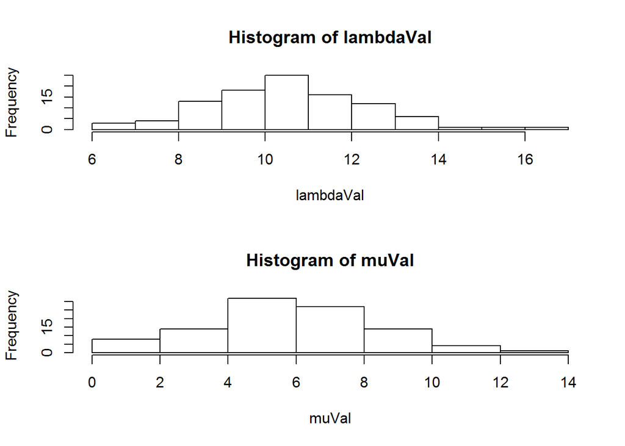

```r
source('rabosky_functions.R')

##Simulate 100 trees

REPS <- 100
lambdaVal <- numeric(REPS)
muVal <- numeric(REPS)
for (i in 1:REPS){

  #  Here we would do the simulation:
  pars <- c(10, 5); #in order: lambda, mu
  tt <- simulateTree(pars, max.taxa=100)
  tt.func <- make.bd(tt)
  tmp <- fitDiversitree(tt.func)

  lambdaVal[i] <- tmp $pars["lambda"]
  muVal[i] <- tmp $pars["mu"]
}
par(mfrow = c(2,1))
hist(lambdaVal)
hist(muVal)
```

## Exercise 2: How much variation is there in a birth-death process?

I ran the simulation for 100 trees with max.t = 1. There is significant variation in the number of species from each tree.

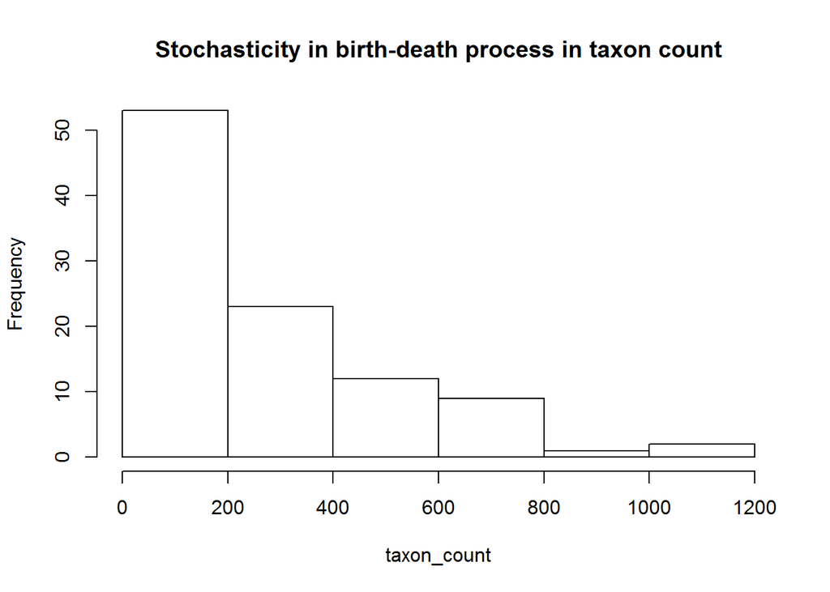

```r
#Variation in bd process
REPS <- 100
taxon_count <- numeric(REPS)
for (i in 1:REPS){
  pars <- c(10, 5)
  tree <- simulateTree(pars, max.t = 1)
  taxon_count[i] <- length(tree$tip.label)

}

#    taxon_count is now a vector
#     of richness: you can plot a histogram
#     with function hist(...)
#     compute mean, quantile, etc.
par(mfrow = c(1, 1))
hist(taxon_count, main = "Stochasticity in birth-death process in taxon count")
```

## Exercise 3:

Trees made with no extinction in general have more evenly distributed waiting times than trees made with extinction.

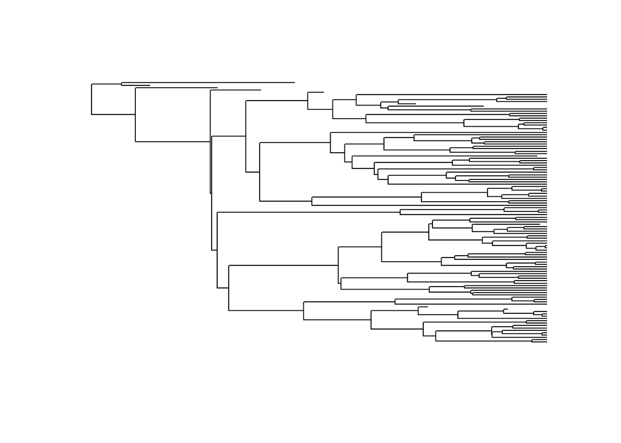

```r
#Lineage Through Time
##
pars <- c(10, 5); #in order: lambda, mu
tt <- simulateTree(pars, max.taxa=100)
ttEx <- sim.bdtree(b = 10, d = 1, stop = "taxa", t = 100, n = 100 )
plot(ttEx, show.tip.label = F)
```

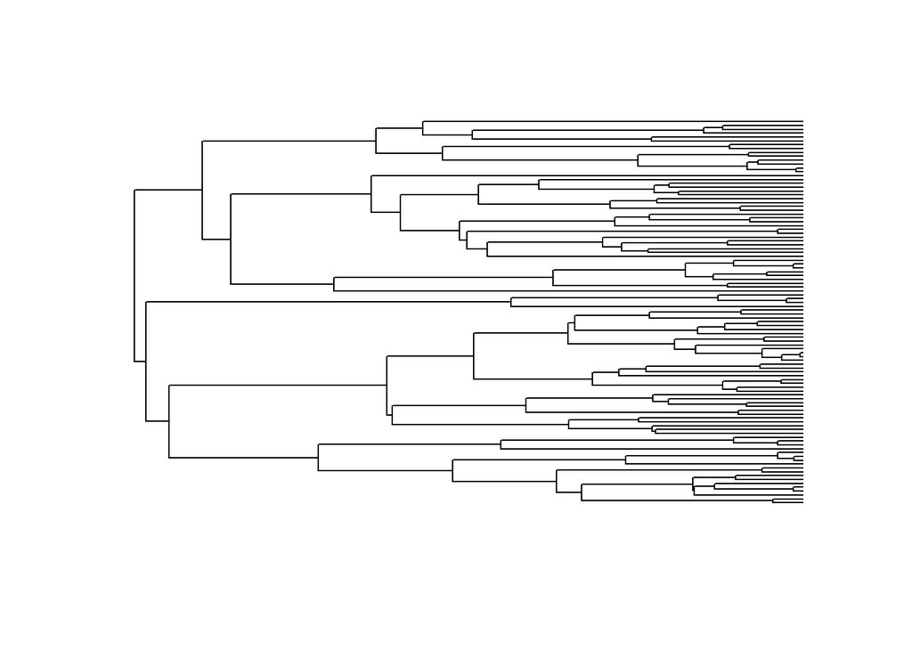

```r
livingOnly <- drop.fossil(ttEx)  #prune out the extinct taxa
plot(livingOnly, show.tip.label = F)
```

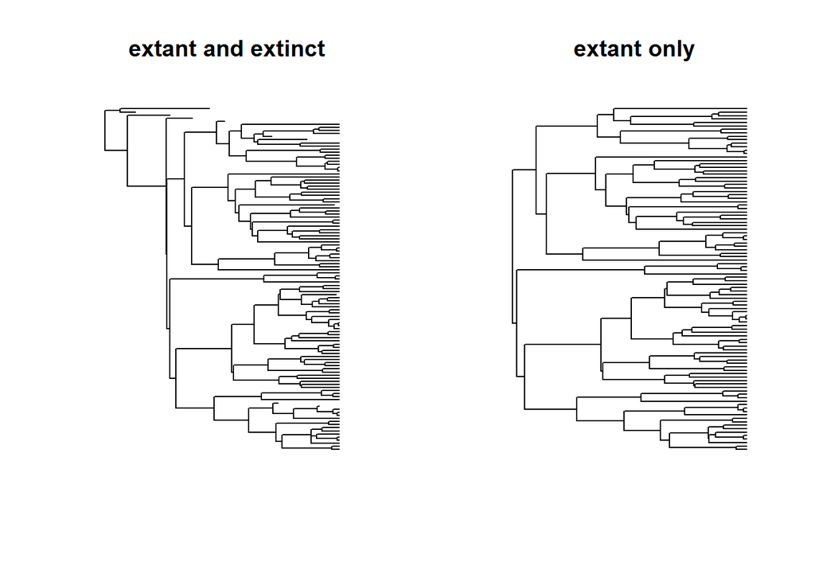

```r
par(mfrow = c(1,2))
plot(ttEx, show.tip.label = F, main = "extant and extinct")
plot(livingOnly, show.tip.label = F, main = "extant only")
```

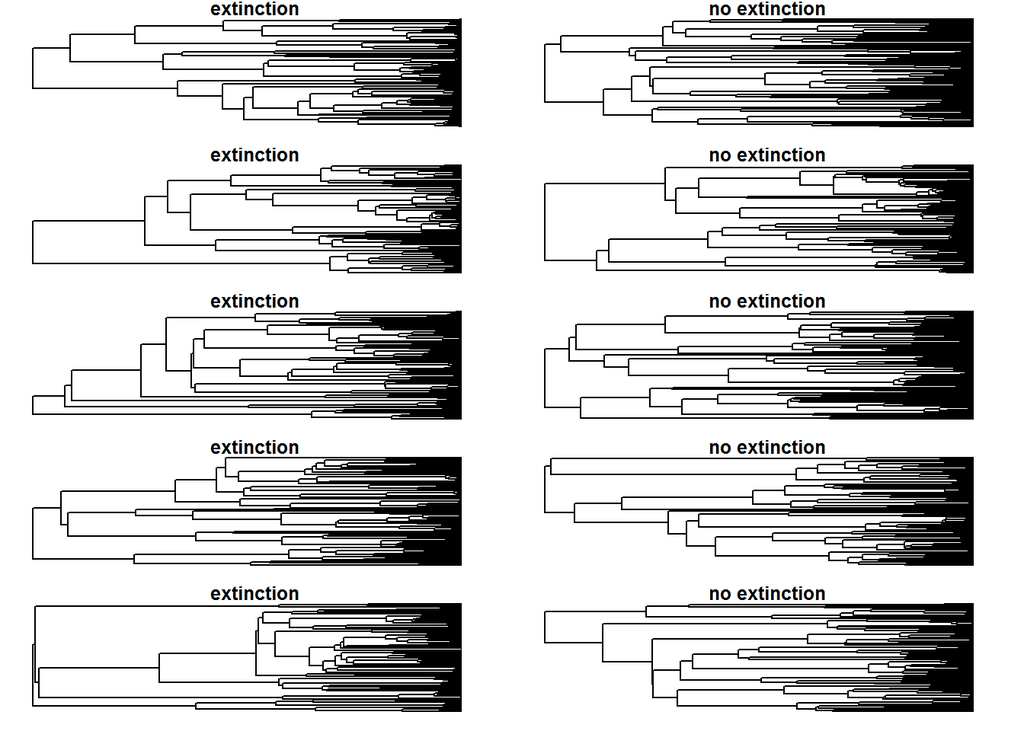

```r
#What does extinction do to the shape of the tree? Simulate 5 trees with and without extinction

treeExlist <- list()  #make empty list for trees to fill in
treeNoExlist <- list()
for (i in 1:5) {
  parsbd <- c(10, 3)
  treeEx <- simulateTree(parsbd, max.taxa = 100, include.extinct = T)
  treeExPruned <- drop.fossil(treeEx)
  treeExlist[[i]] <- treeExPruned  #fill in list with trees
  parspb <- c(7, 0)
  treeNoEx <- simulateTree(parspb, max.taxa = 100)
  treeNoExlist[[i]] <- treeNoEx
}

par(mfrow = c(5,2), mar=c(0.8, 0.8, 0.8, 0.8)) #beware of margins, (margins too big error)
for (i in 1:5) {
  plot(treeExlist[[i]], show.tip.label = F, main = "extinction")
  plot(treeNoExlist[[i]], show.tip.label = F, main = "no extinction")
}
```

```r
for (i in 1:5) {
  ltt(treeExlist[[i]])
  ltt(treeNoExlist[[i]])
}
```

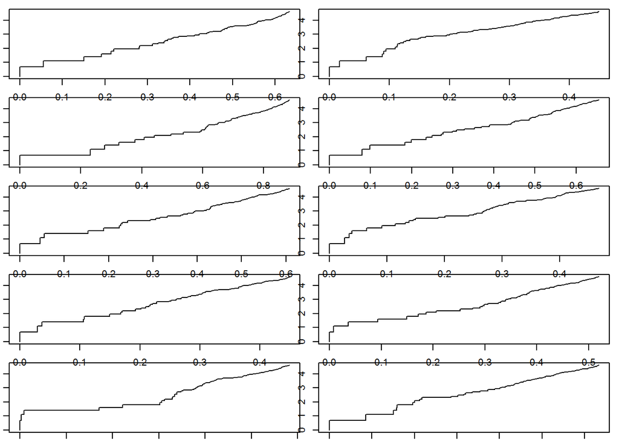

## Exercise 4:

The ltt plot of the density dependent tree does not form a linear plot like the pure-birth tree.

```r
#Diversity-Dependence Model
library(DDD)   #package for diversity dependent diversification
```

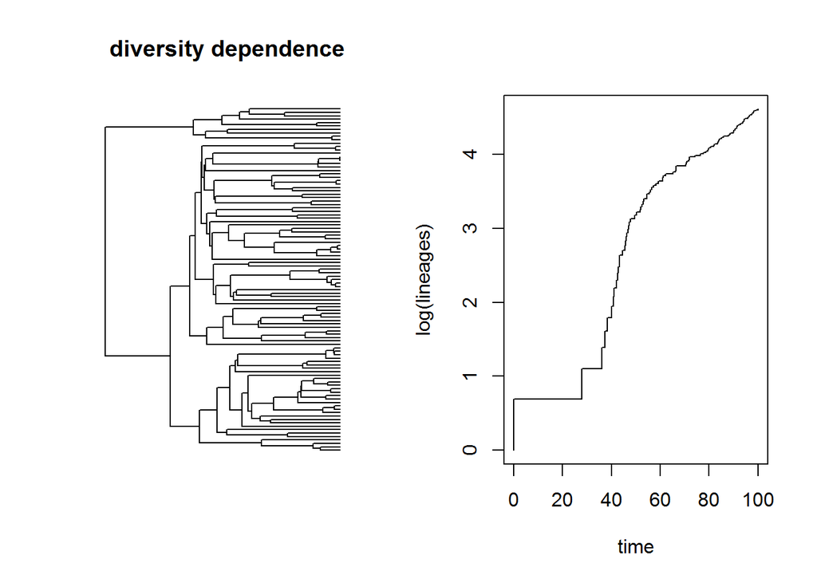

```
## Object of class "ltt" containing:
##
## (1) A phylogenetic tree with 101 tips and 100 internal nodes.
##
## (2) Vectors containing the number of lineages (ltt) and branching times (times) on the tree.
##
## (3) A value for Pybus & Harvey's "gamma" statistic of -2.8348, p-value = 0.0046.
```

```r
ddTree <- dd_sim(c(0.12,0.02,100),100) # pars: c(lambda, mu, K)
#note that ddTree is a list. The tree with extinct members pruned is element 1
ddLivingOnly <- ddTree[[1]]
par(mfrow = c(1,2))
plot(ddLivingOnly, show.tip.label = F, main = "diversity dependence")
ltt(ddLivingOnly)
```

## Exercise 5

```r
library(laser)
snake.times<-getBtimes('homalops.phy')
snake_tree<-read.tree("homalops.phy")
snake.times2<-getBtimes(string = write.tree(snake_tree))
snake.times2
```

```
##  [1] 21.783281 19.698911 19.291015 18.896251 18.190025 17.078195 16.419725
##  [8] 15.900081 14.847855 14.456585 13.782375 12.123975 11.514905 10.507591
## [15]  9.624845  9.128891  4.476151  3.462541  2.871535  1.960470
```

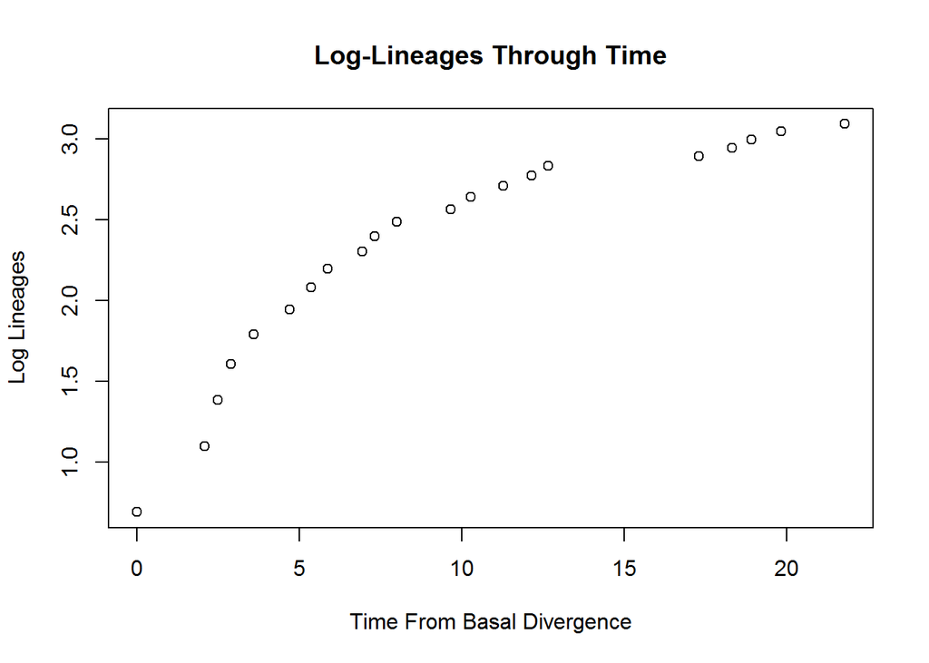

```
##  [1] 0.6931472 1.0986123 1.3862944 1.6094379 1.7917595 1.9459101 2.0794415
##  [8] 2.1972246 2.3025851 2.3978953 2.4849066 2.5649494 2.6390573 2.7080502
## [15] 2.7725887 2.8332133 2.8903718 2.9444390 2.9957323 3.0445224 3.0910425
```

```r
plotLtt(snake.times2)
```

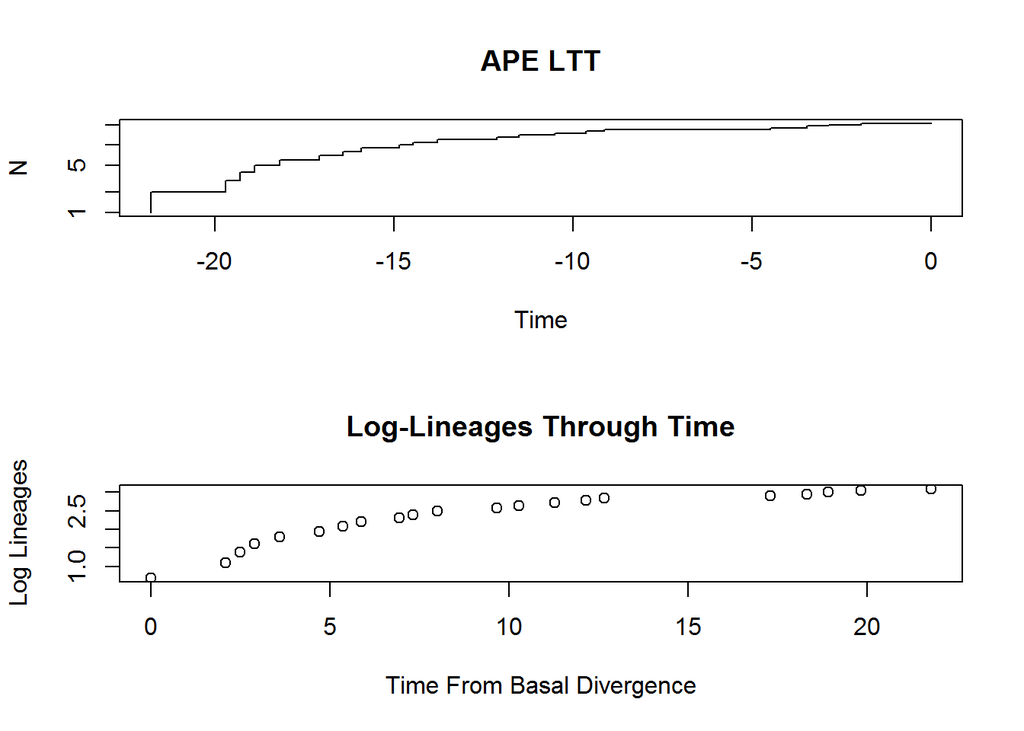

```
##  [1] 0.6931472 1.0986123 1.3862944 1.6094379 1.7917595 1.9459101 2.0794415
##  [8] 2.1972246 2.3025851 2.3978953 2.4849066 2.5649494 2.6390573 2.7080502
## [15] 2.7725887 2.8332133 2.8903718 2.9444390 2.9957323 3.0445224 3.0910425
```

```r
#compare
layout(matrix(1:2, 2,1))
ltt.plot(snake_tree, log="y", main = "APE LTT")
plotLtt(snake.times)
```

```r
##gamma stat
snake_gamma <- gammaStat(snake_tree)
snake_gamma
```

```
## [1] -3.241085
```

```r
##mccrTest(CladeSize, NumberMissing, NumberOfReps, ObservedGamma = NULL, fname=NULL)
mccrResults <- mccrTest(34, 13, 100, ObservedGamma=snake_gamma)  #mccrTest requires laser package
mccrResults
```

```
## $null.gamma
##   [1] -1.02489645 -0.90988135  0.82797648 -1.61729167 -1.62001522
##   [6] -0.98006947 -1.15293440  0.95475277  0.24400719  0.19206157
##  [11] -0.31299448  0.25531976  0.91430268  0.79273134 -2.16648312
##  [16]  0.07692699 -0.15038040  0.82468915 -0.40516624 -3.24086356
##  [21] -2.53785631  1.65423831  0.45755270 -0.92148294 -0.84970563
##  [26] -0.21203041 -1.80594139 -1.11993233 -1.56279284 -1.27045773
##  [31] -1.06903214 -0.60908850 -0.97574110 -0.90005099 -0.99566212
##  [36] -1.64164165 -2.22147805 -1.92274370  0.29873486 -0.13876212
##  [41]  0.35804028 -1.29066860  1.40698175  0.91995208  0.88382848
##  [46] -0.68087932  0.48957465 -1.58417258 -0.99185326 -0.45146278
##  [51] -0.25455826  0.38890735 -2.10783771 -1.11289243 -0.81675553
##  [56] -0.02282254 -1.06185995 -2.17431606 -0.97687582 -0.43711682
##  [61] -0.63324216 -2.04122247 -0.53260886 -0.44017861 -1.64872470
##  [66] -0.80198485 -0.45988890 -1.58309940 -1.24392423 -0.38413758
##  [71] -1.75677578 -2.18368647 -2.30966566 -1.43138594  0.49867265
##  [76] -0.44090484 -1.34471358 -0.97878987  0.02101483 -0.40069383
##  [81] -0.67153890 -1.65405379 -1.31370643 -0.90572530  0.28922290
##  [86]  1.66554422 -0.85097263 -2.02350686 -1.49755320 -0.74821010
##  [91] -0.45143298 -1.01200313  0.22766099  0.07551748 -0.99634234
##  [96] -1.28089748 -0.11614881  0.82234910  0.08527865 -1.18921355
##
## $critical.value
## [1] -2.174785
##
## $p.value
## [1] 0.00990099
```

```r
hist(mccrResults$null.gamma)
abline(v = mccrResults$critical.value, col = 'red')


age <- 22
richness <- 34
snakebirth =  log(richness)/age
snakebirth
```

```
## [1] 0.1602891
```

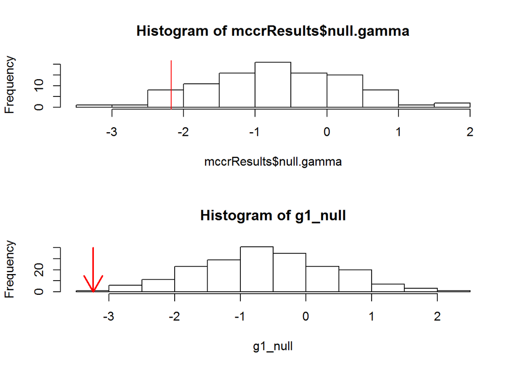

```r
#this simulates gamma values when trees are undersampled.
#we will grow trees with n=34 and prune them down to 13 taxa

num_simulations<-200 #number of simulations
g1_null<-numeric(num_simulations) #g1_null will hold the simulated gamma values
for(i in 1:num_simulations) {
  sim_tree <- sim.bdtree(snakebirth, d=0, stop = "taxa", n=34)
  prune <- drop.random(sim_tree, 13) # prune down to the # of taxa in the phylogeny (34-13=21)
  g1_null[i] <- gammaStat(prune)
}
# create a histogram of the null distribution
hist(g1_null)

#arrow indicates where the observed gamma falls in the null you just generated
arrows(snake_gamma, 40, snake_gamma, 0, col="red", lwd=2)
```

```r
# Which of the null values are smaller (more negative) than the data?
smallerNull <- g1_null<=snake_gamma
# How many TRUEs are there?
count<-sum(smallerNull)
count
```

```
## [1] 0
```

```r
# finally, what is the p-value?
mccr_pval <- (count+1)/(num_simulations+1)
mccr_pval
```

```
## [1] 0.004975124
```

```r
##Fitting diversification models to branching times
#laser works with branching times instead of tree
library(laser)
snake.times <- getBtimes('homalops.phy')

pb <- pureBirth(snake.times) #pb
aic.pb <- pb$aic#store aic score
bd <- bd(snake.times) # birth-death
aic.bd <- bd$aic #store aic
ddl <- DDL(snake.times) # logistic density dependent diversification
aic.ddl <- ddl$aic
ddx <- DDX(snake.times) # exponential density dependent diversification
aic.ddx <- ddx$aic
#the MCCR test above cannot discriminate between early rapid speciation and early slow extinction.
#these models allow those to scenarios to be compared
spvar <- fitSPVAR(snake.times, init=c(2, .2, .1))#variable speciation: exponentially declining speciation, constant extinction rate
aic.spvar <- spvar$aic
exvar <- fitEXVAR(snake.times, init=c(.3, .01, 1))#variable extinction: constant speciation, exponentially increasing extinction rate
aic.exvar <- exvar$aic
both <- fitBOTHVAR(snake.times, init=c(.3, .5, .1, .5))#variable extinction and speciation
aic.both <- both$aic

#make a table and compare them all
aic.all <- cbind(aic.pb, aic.bd, aic.ddl, aic.ddx, aic.spvar, aic.exvar, aic.both)
foo <- function(x) x-x[which(x==min(x))] #quick function to compare all models to the model with lowest aic score
daic <- t(apply(aic.all, 1, foo))#apply that function to everything in aic.all
cat("Table of delta-aic values; zero - best model\n")
```

```
## Table of delta-aic values; zero - best model
```

```r
print(daic, digits=2)
```

```
##    aic.pb aic.bd aic.ddl aic.ddx aic.spvar aic.exvar aic.both
## LH     12     14       0     1.8       4.5        17      6.6
```

### What would you conclude from this table? How is this different from what you can say after the MCCR test?

The table indicates that the logistic diversity dependent model is the best fit. This is also consistent with the MCCR test.

## Exercise 6

```r
balistoid.tree <- read.tree("balistoids.phy")
balistoid.times <- getBtimes("balistoids.phy")

balistoid.gamma <- gammaStat(balistoid.tree)
balistoid.gamma
```

```
## [1] 0.3488196
```

```r
age <- 48
richness <- 86
balistoidbirth =  log(richness)/age
balistoidbirth
```

```
## [1] 0.0927989
```

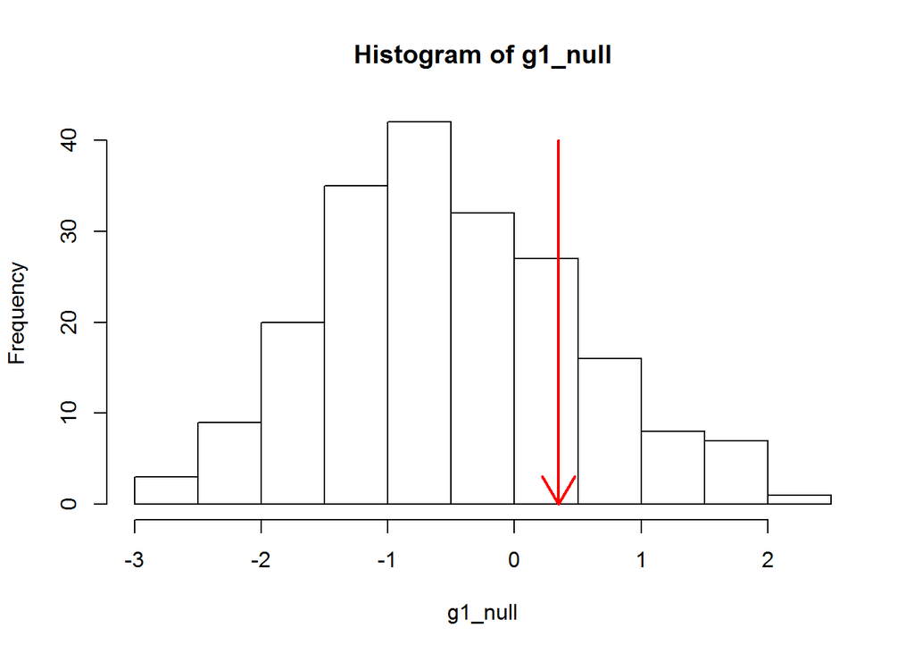

```r
num_simulations<-200 #number of simulations
g1_null<-numeric(num_simulations) #g1_null will hold the simulated gamma values
for(i in 1:num_simulations) {
  sim_tree <- sim.bdtree(balistoidbirth, d=0, stop = "taxa", n=100)
  prune <- drop.random(sim_tree, 100-86) # prune down to the # of taxa in the phylogeny (34-13=21)
  g1_null[i] <- gammaStat(prune)
}
hist(g1_null)

arrows(balistoid.gamma, 40, balistoid.gamma, 0, col="red", lwd=2)
```

```r
# Which of the null values are smaller (more negative) than the data?
smallerNull <- g1_null<=balistoid.gamma
# How many TRUEs are there?
count<-sum(smallerNull)
count
```

```
## [1] 161
```

```r
# finally, what is the p-value?
mccr_pval <- (count+1)/(num_simulations+1)
mccr_pval
```

```
## [1] 0.8059701
```

```r
pb <- pureBirth(balistoid.times) #pb
aic.pb <- pb$aic#store aic score
bd <- bd(balistoid.times) # birth-death
aic.bd <- bd$aic #store aic
ddl <- DDL(balistoid.times) # logistic density dependent diversification
aic.ddl <- ddl$aic
ddx <- DDX(balistoid.times) # exponential density dependent diversification
aic.ddx <- ddx$aic
#the MCCR test above cannot discriminate between early rapid speciation and early slow extinction.
#these models allow those to scenarios to be compared
spvar <- fitSPVAR(balistoid.times, init=c(2, .2, .1))#variable speciation: exponentially declining speciation, constant extinction rate
aic.spvar <- spvar$aic
exvar <- fitEXVAR(balistoid.times, init=c(.3, .01, 1))#variable extinction: constant speciation, exponentially increasing extinction rate
aic.exvar <- exvar$aic
both <- fitBOTHVAR(balistoid.times, init=c(.3, .5, .1, .5))#variable extinction and speciation
aic.both <- both$aic

#make a table and compare them all
aic.all <- cbind(aic.pb, aic.bd, aic.ddl, aic.ddx, aic.spvar, aic.exvar, aic.both)
foo <- function(x) x-x[which(x==min(x))] #quick function to compare all models to the model with lowest aic score
daic <- t(apply(aic.all, 1, foo))#apply that function to everything in aic.all
cat("Table of delta-aic values; zero - best model\n")
```

```
## Table of delta-aic values; zero - best model
```

```r
print(daic, digits=2)
```

```
##    aic.pb aic.bd aic.ddl aic.ddx aic.spvar aic.exvar aic.both
## LH      0    1.8       2     1.8       3.9       3.8      5.9
```

The pure-birth model fits best for the balistoid tree. This is consistent with a gamma near 0.